# Tarea3_Oscar_Salas

Oscar Salas

7 de julio de 2019

**1. Utilizando los paquetes devtools, usethis, packrat y el dataset Datos Churn.csv cree un proyecto de RStudio y realice los siguientes ejercicios:**

**a) Cree la estructura de carpetas para su proyecto y documente cuÃ¡l es el objetivo de cada una de las carpetas.**

```
install.packages("usethis")
library(usethis)
create_project("D:/perfil/Documents/GitHub/Tarea3.1R/ProyectoChurn")

use_directory("R")
use_directory("R/preparation")
use_directory("R/processing")
use_directory("R/modeling")
use_directory("test")
use_directory("data")
use_directory("reports")
```

Objetivo de las carpetas

**R/Preparation:** Almacenar el codigo de lectura de datos

**R/processing:** Almacenar el codigo para la realizacion de algunas trasnformaciones de variables y limpieza

**R/modeling:** Almacenar el codigo de la construccion del modelo

**Test:** Validar la existencia de NA

**data**: Copiar los resultados obtenidos para evitar repetir el proceso cuando vaya a construir el reporte

**Reports**: Almacenar el archivo de reporte Rmarkdown

2. Respetando la estructura de carpetas seleccionada realice un anáisis exploratorio que cuente como mínimo con las siguientes etapas:
1. Lectura de datos (csv o xlsx). ok
2. TransformaciÃ³n y limpieza de los datos. ok
3. Analisis exploratorio de los datos. ok
4. Reporte de los resultados utilizando Rmarkdown.

```r
Datos_churn_limpioTransformado <- read.csv("D:/perfil/Documents/GitHub/Tarea3.1R/ProyectoChurn/data/Datos_churn_limpioTransformado.csv")

summary(Datos_churn_limpioTransformado)
```

```
##       X.1             X           IdCliente           Apellido
##  Min.   :   1   Min.   :    2   Min.   :15565714   Smith  :  22
##  1st Qu.:1708   1st Qu.: 2511   1st Qu.:15627842   Walker :  22
##  Median :3416   Median : 5003   Median :15690673   Martin :  21
##  Mean   :3416   Mean   : 5000   Mean   :15690886   Brown  :  20
##  3rd Qu.:5124   3rd Qu.: 7490   3rd Qu.:15754145   Scott  :  19
##  Max.   :6831   Max.   :10000   Max.   :15815690   Shih   :  19
##                                                    (Other):6708
##  ScoringCrediticio       Pais            Genero          Edad
##  Min.   :350.0     Alemania:1692   Femenino :3082   Min.   :18.00
##  1st Qu.:583.0     EspaÃÂ±a :1717   Masculino:3749   1st Qu.:32.00
##  Median :651.0     Francia :3422                    Median :37.00
##  Mean   :649.7                                      Mean   :38.89
##  3rd Qu.:716.0                                      3rd Qu.:44.00
##  Max.   :850.0                                      Max.   :92.00
##
##     IdCuenta     BalanceCuenta    CantidadProductos TarjetaCredito
##  Min.   : 1001   Min.   :     0   Min.   :1.000     Min.   :0.0000
##  1st Qu.: 3527   1st Qu.:     0   1st Qu.:1.000     1st Qu.:0.0000
##  Median : 6046   Median : 96858   Median :1.000     Median :1.0000
##  Mean   : 6026   Mean   : 75999   Mean   :1.528     Mean   :0.7033
##  3rd Qu.: 8548   3rd Qu.:127436   3rd Qu.:2.000     3rd Qu.:1.0000
##  Max.   :10999   Max.   :238388   Max.   :4.000     Max.   :1.0000
##
##      Activo       SalarioEstimado       DejaBanco       SalarioNuevo
##  Min.   :0.0000   Min.   :    11.58   Min.   :0.0000   Min.   :    13.78
##  1st Qu.:0.0000   1st Qu.: 49654.83   1st Qu.:0.0000   1st Qu.: 59089.25
##  Median :1.0000   Median : 97938.59   Median :0.0000   Median :116546.92
##  Mean   :0.5176   Mean   : 99036.24   Mean   :0.2042   Mean   :117853.12
##  3rd Qu.:1.0000   3rd Qu.:148689.39   3rd Qu.:0.0000   3rd Qu.:176940.37
##  Max.   :1.0000   Max.   :199970.74   Max.   :1.0000   Max.   :237965.18
##
```

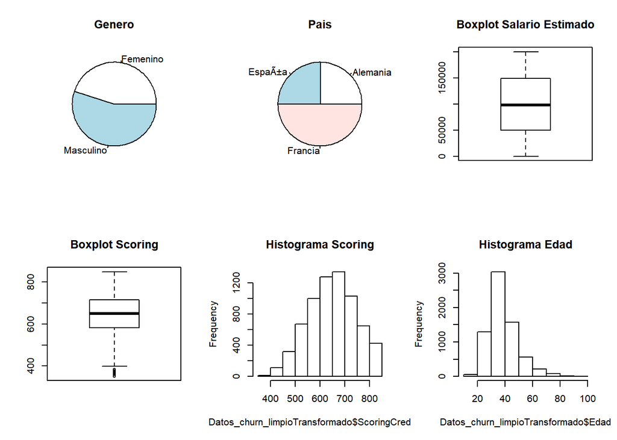

```r
Conf3x2 = matrix(c(1:6), nrow=2, byrow=TRUE)
layout(Conf3x2)


  pie(table(Datos_churn_limpioTransformado$Genero),main="Genero") # Scatter plot.

  pie(table(Datos_churn_limpioTransformado$Pais),main="Pais") # Diagrama de cajas y bigotes o boxplot.

  boxplot(Datos_churn_limpioTransformado$SalarioEstimado,main="Boxplot Salario Estimado") # Diagrama de cajas y bigotes o boxplot en funciÃ³n de una variable con dos niveles.

  boxplot(Datos_churn_limpioTransformado$ScoringCrediticio,main="Boxplot Scoring")

  hist(Datos_churn_limpioTransformado$ScoringCrediticio, nclass=10, main="Histograma Scoring")

  hist(Datos_churn_limpioTransformado$Edad, nclass=10, main="Histograma Edad") # Histograma.
```

3. Publique su proyecto en Github y adjunte el enlace del repositorio pÃºblico creado para el proyecto.

https://github.com/salascorp/Tarea3.1R

```r
summary(iris)
```

```
##   Sepal.Length    Sepal.Width     Petal.Length    Petal.Width
##  Min.   :4.300   Min.   :2.000   Min.   :1.000   Min.   :0.100
##  1st Qu.:5.100   1st Qu.:2.800   1st Qu.:1.600   1st Qu.:0.300
##  Median :5.800   Median :3.000   Median :4.350   Median :1.300
##  Mean   :5.843   Mean   :3.057   Mean   :3.758   Mean   :1.199
##  3rd Qu.:6.400   3rd Qu.:3.300   3rd Qu.:5.100   3rd Qu.:1.800
##  Max.   :7.900   Max.   :4.400   Max.   :6.900   Max.   :2.500
##        Species
##  setosa    :50
##  versicolor:50
##  virginica :50
##
##
##
```